# Data Visualisation and Analytics using Linear Regression

## Dataset Description

This data contain houses listing in Melbroune. The data was scrapped from publicly available result posted every week from Domain.com.au. There are several key details about the data including:

- Suburb: Suburb
- Address: Address
- Rooms: Number of rooms
- Price: Price in Australian dollars
- Method:
  - S - property sold;
  - SP - property sold prior;
  - PI - property passed in;
  - PN - sold prior not disclosed;
  - SN - sold not disclosed;
  - NB - no bid;
  - VB - vendor bid;
  - W - withdrawn prior to auction;
  - SA - sold after auction;
  - SS - sold after auction price not disclosed.
  - N/A - price or highest bid not available.
- Type:
  - br - bedroom(s);
  - h - house,cottage,villa, semi,terrace;
  - u - unit, duplex;
  - t - townhouse;
  - dev site - development site;
  - o res - other residential.
- SellerG: Real Estate Agent
- Date: Date sold
- Distance: Distance from CBD in Kilometres
- Regionname: General Region (West, North West, North, North east .etc)
- Propertycount: Number of properties that exist in the suburb.
- Bedroom2: Scraped - of Bedrooms (from different source)
- Bathroom: Number of Bathrooms
- Car: Number of carspots
- Landsize: Land Size in Metres
- BuildingArea: Building Size in Metres
- YearBuilt: Year the house was built
- CouncilArea: Governing council for the area
- Lattitude: Self explanitory
- Longtitude: Self explanitory

## Goal:

Create linear regression model to predict house price in region that has largest potencial in terms of price growth

### Load Dataset and Data Preprocessing

```r
# Read Dataset
df_raw = read.csv("D:/Kuliah/Semester 1/Data Mining dan Business Intelligence/Pertemuan 6/Tugas/Melbourne_housing_FULL.csv", sep=';')
str(df_raw)
```

```
## 'data.frame':    34857 obs. of  21 variables:
##  $ Suburb       : chr  "Abbotsford" "Abbotsford" "Abbotsford" "Abbotsford" ...
##  $ Address      : chr  "68 Studley St" "85 Turner St" "25 Bloomburg St" "18/659 Victoria St" ...
##  $ Rooms        : int  2 2 2 3 3 3 4 4 2 2 ...
##  $ Type         : chr  "h" "h" "h" "u" ...
##  $ Price        : int  NA 1480000 1035000 NA 1465000 850000 1600000 NA NA NA ...
##  $ Method       : chr  "SS" "S" "S" "VB" ...
##  $ SellerG      : chr  "Jellis" "Biggin" "Biggin" "Rounds" ...
##  $ Date         : chr  "03/09/2016" "03/12/2016" "04/02/2016" "04/02/2016" ...
##  $ Distance     : chr  "2.5" "2.5" "2.5" "2.5" ...
##  $ Postcode     : chr  "3067" "3067" "3067" "3067" ...
##  $ Bedroom2     : int  2 2 2 3 3 3 3 3 4 3 ...
##  $ Bathroom     : int  1 1 1 2 2 2 1 2 1 2 ...
##  $ Car          : int  1 1 0 1 0 1 2 2 2 1 ...
##  $ Landsize     : int  126 202 156 0 134 94 120 400 201 202 ...
##  $ BuildingArea : chr  "" "" "79" "" ...
##  $ YearBuilt    : int  NA NA 1900 NA 1900 NA 2014 2006 1900 1900 ...
##  $ CouncilArea  : chr  "Yarra City Council" "Yarra City Council" "Yarra City Council" "Yarra City Council" ...
##  $ Lattitude    : chr  "-378.014" "-377.996" "-378.079" "-378.114" ...
##  $ Longtitude   : chr  "1.449.958" "1.449.984" "1.449.934" "1.450.116" ...
##  $ Regionname   : chr  "Northern Metropolitan" "Northern Metropolitan" "Northern Metropolitan" "Northern Metropolitan" ...
##  $ Propertycount: chr  "4019" "4019" "4019" "4019" ...
```

Propertycount and BuildingArea were missidentified as character, so we need to transform it to numeric variable  
Source of method:  
- https://statisticsglobe.com/convert-data-frame-column-to-numeric-in-r  
- https://www.statmethods.net/input/dates.html

```r
df_dt = df_raw
i = c(15,21)
df_dt[,i] = apply(df_dt[,i],2,function(x) as.numeric(as.character(x)))
sapply(df_dt, class)
```

```
##        Suburb       Address         Rooms          Type         Price
##   "character"   "character"     "integer"   "character"     "integer"
##        Method       SellerG          Date      Distance      Postcode
##   "character"   "character"   "character"   "character"   "character"
##      Bedroom2      Bathroom           Car      Landsize  BuildingArea
##     "integer"     "integer"     "integer"     "integer"     "numeric"
##     YearBuilt   CouncilArea     Lattitude    Longtitude    Regionname
##     "integer"   "character"   "character"   "character"   "character"
## Propertycount
##     "numeric"
```

```r
df_dt$DateFormat = as.Date(df_dt$Date, format="%d/%m/%Y")
df_dt$Year = as.numeric(format(df_dt$DateFormat, format="%Y"))
df_dt$Month = as.numeric(format(df_dt$DateFormat, format="%m"))
df_dt$Day = as.numeric(format(df_dt$DateFormat, format="%d"))

df_dt_fe = df_dt
str(df_dt_fe)
```

```
## 'data.frame':    34857 obs. of  25 variables:
##  $ Suburb       : chr  "Abbotsford" "Abbotsford" "Abbotsford" "Abbotsford" ...
##  $ Address      : chr  "68 Studley St" "85 Turner St" "25 Bloomburg St" "18/659 Victoria St" ...
##  $ Rooms        : int  2 2 2 3 3 3 4 4 2 2 ...
##  $ Type         : chr  "h" "h" "h" "u" ...
##  $ Price        : int  NA 1480000 1035000 NA 1465000 850000 1600000 NA NA NA ...
##  $ Method       : chr  "SS" "S" "S" "VB" ...
##  $ SellerG      : chr  "Jellis" "Biggin" "Biggin" "Rounds" ...
##  $ Date         : chr  "03/09/2016" "03/12/2016" "04/02/2016" "04/02/2016" ...
##  $ Distance     : chr  "2.5" "2.5" "2.5" "2.5" ...
##  $ Postcode     : chr  "3067" "3067" "3067" "3067" ...
##  $ Bedroom2     : int  2 2 2 3 3 3 3 3 4 3 ...
##  $ Bathroom     : int  1 1 1 2 2 2 1 2 1 2 ...
##  $ Car          : int  1 1 0 1 0 1 2 2 2 1 ...
##  $ Landsize     : int  126 202 156 0 134 94 120 400 201 202 ...
##  $ BuildingArea : num  NA NA 79 NA 150 NA 142 220 NA NA ...
##  $ YearBuilt    : int  NA NA 1900 NA 1900 NA 2014 2006 1900 1900 ...
##  $ CouncilArea  : chr  "Yarra City Council" "Yarra City Council" "Yarra City Council" "Yarra City Council" ...
##  $ Lattitude    : chr  "-378.014" "-377.996" "-378.079" "-378.114" ...
##  $ Longtitude   : chr  "1.449.958" "1.449.984" "1.449.934" "1.450.116" ...
##  $ Regionname   : chr  "Northern Metropolitan" "Northern Metropolitan" "Northern Metropolitan" "Northern Metropolitan" ...
##  $ Propertycount: num  4019 4019 4019 4019 4019 ...
##  $ DateFormat   : Date, format: "2016-09-03" "2016-12-03" ...
##  $ Year         : num  2016 2016 2016 2016 2017 ...
##  $ Month        : num  9 12 2 2 3 3 6 8 8 8 ...
##  $ Day          : num  3 3 4 4 4 4 4 6 6 6 ...
```

## Descriptive Statistics

```r
summary(df_dt_fe)
```

```
##     Suburb            Address              Rooms            Type
##  Length:34857       Length:34857       Min.   : 1.000   Length:34857
##  Class :character   Class :character   1st Qu.: 2.000   Class :character
##  Mode  :character   Mode  :character   Median : 3.000   Mode  :character
##                                        Mean   : 3.031
##                                        3rd Qu.: 4.000
##                                        Max.   :16.000
##
##      Price             Method            SellerG              Date
##  Min.   :   85000   Length:34857       Length:34857       Length:34857
##  1st Qu.:  635000   Class :character   Class :character   Class :character
##  Median :  870000   Mode  :character   Mode  :character   Mode  :character
##  Mean   : 1050173
##  3rd Qu.: 1295000
##  Max.   :11200000
##  NA's   :7610
##    Distance           Postcode            Bedroom2         Bathroom
##  Length:34857       Length:34857       Min.   : 0.000   Min.   : 0.000
##  Class :character   Class :character   1st Qu.: 2.000   1st Qu.: 1.000
##  Mode  :character   Mode  :character   Median : 3.000   Median : 2.000
##                                        Mean   : 3.085   Mean   : 1.625
##                                        3rd Qu.: 4.000   3rd Qu.: 2.000
##                                        Max.   :30.000   Max.   :12.000
##                                        NA's   :8217     NA's   :8226
##       Car            Landsize         BuildingArea       YearBuilt
##  Min.   : 0.000   Min.   :     0.0   Min.   :    0.0   Min.   :1196
##  1st Qu.: 1.000   1st Qu.:   224.0   1st Qu.:  102.0   1st Qu.:1940
##  Median : 2.000   Median :   521.0   Median :  136.0   Median :1970
##  Mean   : 1.729   Mean   :   593.6   Mean   :  160.2   Mean   :1965
##  3rd Qu.: 2.000   3rd Qu.:   670.0   3rd Qu.:  188.0   3rd Qu.:2000
##  Max.   :26.000   Max.   :433014.0   Max.   :44515.0   Max.   :2106
##  NA's   :8728     NA's   :11810      NA's   :21121     NA's   :19306
##  CouncilArea         Lattitude          Longtitude         Regionname
##  Length:34857       Length:34857       Length:34857       Length:34857
##  Class :character   Class :character   Class :character   Class :character
##  Mode  :character   Mode  :character   Mode  :character   Mode  :character
##
##
##
##
##  Propertycount     DateFormat              Year          Month
##  Min.   :   83   Min.   :2016-01-28   Min.   :2016   Min.   : 1.000
##  1st Qu.: 4385   1st Qu.:2016-11-19   1st Qu.:2016   1st Qu.: 5.000
##  Median : 6763   Median :2017-07-08   Median :2017   Median : 7.000
##  Mean   : 7573   Mean   :2017-05-23   Mean   :2017   Mean   : 7.142
##  3rd Qu.:10412   3rd Qu.:2017-10-28   3rd Qu.:2017   3rd Qu.:10.000
##  Max.   :21650   Max.   :2018-03-17   Max.   :2018   Max.   :12.000
##  NA's   :3
##       Day
##  Min.   : 1.00
##  1st Qu.: 9.00
##  Median :17.00
##  Mean   :15.88
##  3rd Qu.:24.00
##  Max.   :30.00
##
```

### Filter data

```r
#df_dt_fe = subset(df_dt_fe, df_dt_fe$Method=='S')
df_dt_fe = subset(df_dt_fe, df_dt_fe$Type=='h'|df_dt_fe$Type=='t')
#head(df_dt_fe)
```

### Visualizing mean house price sold per region name

```r
library(dplyr)
```

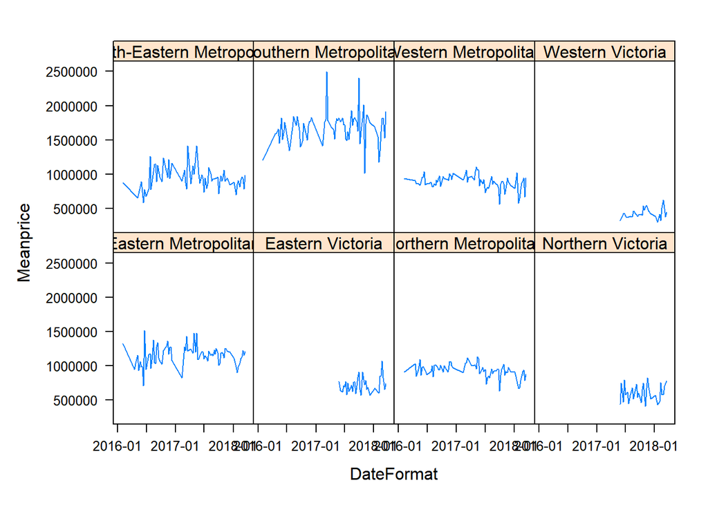

```r
library(lattice)

df_dt_fe_fil <-
  df_dt_fe %>%
  select(DateFormat,Price,Regionname,Propertycount)%>%
  na.omit()%>%
  group_by(DateFormat, Regionname) %>%
  summarise(Meanprice = mean(Price),
            MeanProperty = mean(Propertycount),
            .groups='drop') %>%
  xyplot(x=Meanprice ~ DateFormat|Regionname, type='l', scales=list(alternating=FALSE, tck=1:0, xlab=2))

df_dt_fe_fil
```

### Filter data

Filter the data for Regionname = Southern Metropolitan

```r
df_dt_fe = subset(df_dt_fe, df_dt_fe$Regionname=='Southern Metropolitan')
#head(df_dt_fe)
count(df_dt_fe)
```

```
##      n
## 1 8300
```

### Check null values

```r
lapply(df_dt_fe,function(x) { length(which(is.na(x)))})
```

```
## $Suburb
## [1] 0
##
## $Address
## [1] 0
##
## $Rooms
## [1] 0
##
## $Type
## [1] 0
##
## $Price
## [1] 2558
##
## $Method
## [1] 0
##
## $SellerG
## [1] 0
##
## $Date
## [1] 0
##
## $Distance
## [1] 0
##
## $Postcode
## [1] 0
##
## $Bedroom2
## [1] 1676
##
## $Bathroom
## [1] 1681
##
## $Car
## [1] 1820
##
## $Landsize
```

[output cut: 19 more lines]

```
##
## $Propertycount
## [1] 0
##
## $DateFormat
## [1] 0
##
## $Year
## [1] 0
##
## $Month
## [1] 0
##
## $Day
## [1] 0
```

```r
unique(df_dt_fe$Suburb)
```

```
##  [1] "Albert Park"     "Armadale"        "Ashburton"       "Ashwood"
##  [5] "Balaclava"       "Balwyn"          "Balwyn North"    "Bentleigh"
##  [9] "Bentleigh East"  "Brighton"        "Brighton East"   "Burwood"
## [13] "Camberwell"      "Canterbury"      "Carnegie"        "Caulfield"
## [17] "Caulfield North" "Caulfield South" "Chadstone"       "Elsternwick"
## [21] "Elwood"          "Glen Iris"       "Hampton"         "Hampton East"
## [25] "Hawthorn"        "Hughesdale"      "Kew"             "Kew East"
## [29] "Kooyong"         "Malvern"         "Malvern East"    "Middle Park"
## [33] "Moorabbin"       "Port Melbourne"  "Prahran"         "South Melbourne"
## [37] "South Yarra"     "Southbank"       "St Kilda"        "Surrey Hills"
## [41] "Toorak"          "Windsor"         "Hawthorn East"   "Murrumbeena"
## [45] "Ormond"          "Glen Huntly"     "Oakleigh"        "Ripponlea"
## [49] "Docklands"       "Caulfield East"  "Gardenvale"      "Beaumaris"
## [53] "Cheltenham"      "Huntingdale"     "Oakleigh East"   "Black Rock"
## [57] "Highett"         "McKinnon"        "Sandringham"     "Deepdene"
## [61] "Notting Hill"
```

```r
df_dt_fe_na = na.omit(df_dt_fe)
count(df_dt_fe_na)
```

```
##      n
## 1 1956
```

```r
lapply(df_dt_fe_na,function(x) { length(which(is.na(x)))})
```

```
## $Suburb
## [1] 0
##
## $Address
## [1] 0
##
## $Rooms
## [1] 0
##
## $Type
## [1] 0
##
## $Price
## [1] 0
##
## $Method
## [1] 0
##
## $SellerG
## [1] 0
##
## $Date
## [1] 0
##
## $Distance
## [1] 0
##
## $Postcode
## [1] 0
##
## $Bedroom2
## [1] 0
##
## $Bathroom
## [1] 0
##
## $Car
## [1] 0
##
## $Landsize
```

[output cut: 19 more lines]

```
##
## $Propertycount
## [1] 0
##
## $DateFormat
## [1] 0
##
## $Year
## [1] 0
##
## $Month
## [1] 0
##
## $Day
## [1] 0
```

### Data Visualisation

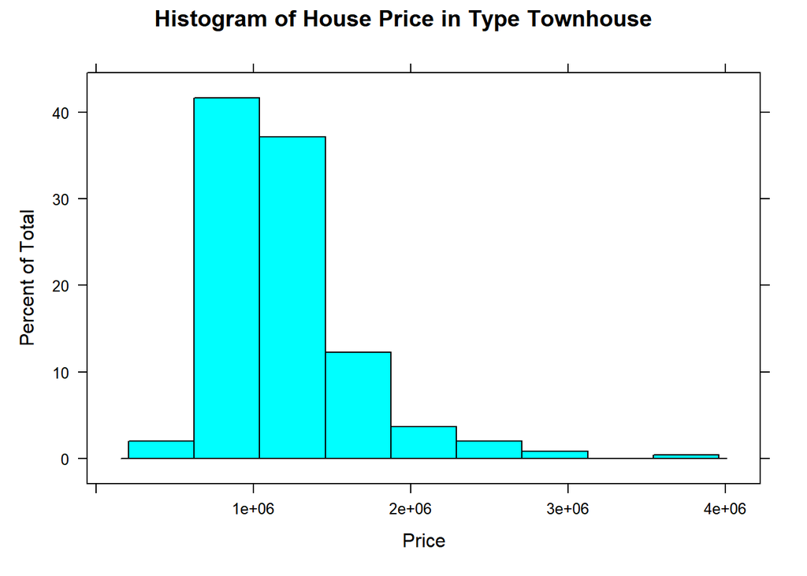

```r
histogram(~Price, data=subset(df_dt_fe_na, df_dt_fe_na$Type=='t'), main="Histogram of House Price in Type Townhouse")
```

The majority of townhouse price in Southern Metropolitan is in range of approximately AUD 600.000 to AUD 1.400.000

### Data Visualisation

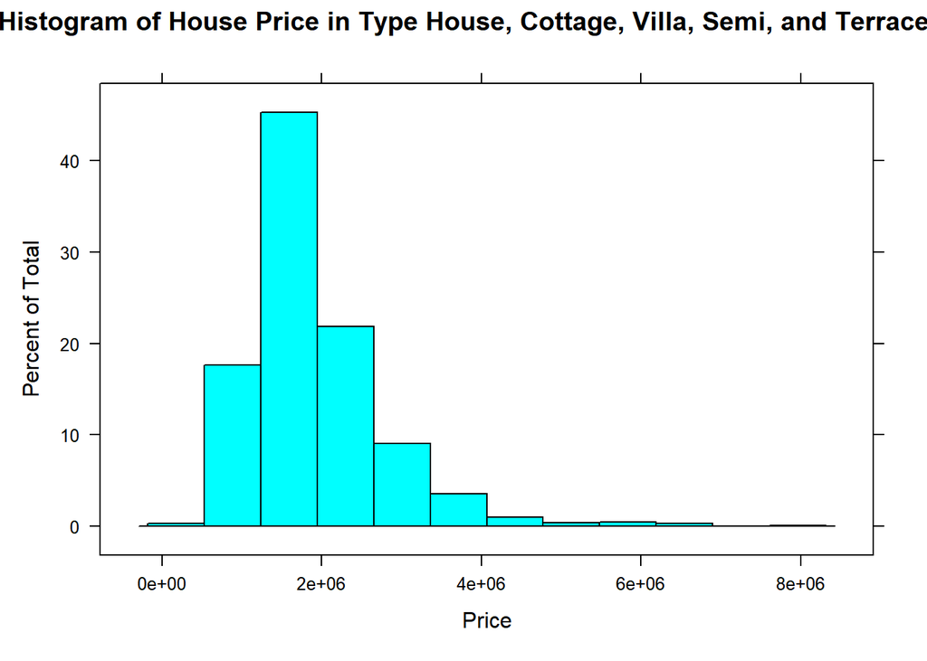

```r
histogram(~Price, data=subset(df_dt_fe_na, df_dt_fe_na$Type=='h'), main="Histogram of House Price in Type House, Cottage, Villa, Semi, and Terrace")
```

The majority of House, Cottage, Villa, Semi, and Terrace price in Southern Metropolitan is in range of approximately AUD 1.000.000 to AUD 2.000.000

### Drop Char Column

```r
names(df_dt_fe_na)
```

```
##  [1] "Suburb"        "Address"       "Rooms"         "Type"
##  [5] "Price"         "Method"        "SellerG"       "Date"
##  [9] "Distance"      "Postcode"      "Bedroom2"      "Bathroom"
## [13] "Car"           "Landsize"      "BuildingArea"  "YearBuilt"
## [17] "CouncilArea"   "Lattitude"     "Longtitude"    "Regionname"
## [21] "Propertycount" "DateFormat"    "Year"          "Month"
## [25] "Day"
```

```r
df_dt_fe_na_dc = df_dt_fe_na[c(-1, -2, -4, -6, -7, -8, -10, -17, -18, -19, -20,-22, -23, -24, -25)]
str(df_dt_fe_na_dc)
```

```
## 'data.frame':    1956 obs. of  10 variables:
##  $ Rooms        : int  2 3 3 2 4 3 2 3 3 3 ...
##  $ Price        : int  1275000 2850000 1850000 1436000 2300000 1800000 2120000 1800000 2615000 1370000 ...
##  $ Distance     : chr  "3.3" "3.3" "3.3" "3.3" ...
##  $ Bedroom2     : int  2 3 3 2 4 3 2 3 3 3 ...
##  $ Bathroom     : int  1 2 2 1 2 2 1 2 2 2 ...
##  $ Car          : int  0 0 0 0 1 1 1 1 1 2 ...
##  $ Landsize     : int  120 211 128 130 153 132 199 90 177 0 ...
##  $ BuildingArea : num  82 198 133 81 180 159 107 122 181 85 ...
##  $ YearBuilt    : int  1900 1890 1890 1900 1880 1996 1900 1900 1880 2000 ...
##  $ Propertycount: num  3280 3280 3280 3280 3280 3280 3280 3280 3280 3280 ...
```

```r
#install.packages("psych")
library(psych)

str(df_dt_fe_na_dc)
```

```
## 'data.frame':    1956 obs. of  10 variables:
##  $ Rooms        : int  2 3 3 2 4 3 2 3 3 3 ...
##  $ Price        : int  1275000 2850000 1850000 1436000 2300000 1800000 2120000 1800000 2615000 1370000 ...
##  $ Distance     : chr  "3.3" "3.3" "3.3" "3.3" ...
##  $ Bedroom2     : int  2 3 3 2 4 3 2 3 3 3 ...
##  $ Bathroom     : int  1 2 2 1 2 2 1 2 2 2 ...
##  $ Car          : int  0 0 0 0 1 1 1 1 1 2 ...
##  $ Landsize     : int  120 211 128 130 153 132 199 90 177 0 ...
##  $ BuildingArea : num  82 198 133 81 180 159 107 122 181 85 ...
##  $ YearBuilt    : int  1900 1890 1890 1900 1880 1996 1900 1900 1880 2000 ...
##  $ Propertycount: num  3280 3280 3280 3280 3280 3280 3280 3280 3280 3280 ...
```

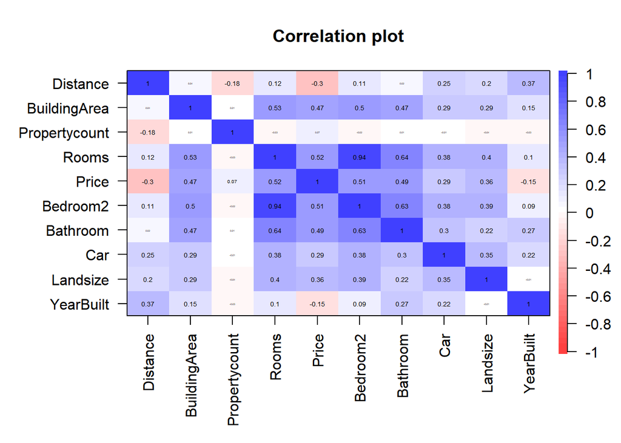

```r
chars<-sapply(df_dt_fe_na_dc, is.character)
#chars

ints<-sapply(df_dt_fe_na_dc, is.integer)
#ints

df_dt_fe_na_dc$Distance = as.numeric(df_dt_fe_na_dc$Distance)
df_dt_fe_na_dc_int = as.data.frame(apply(df_dt_fe_na_dc[,ints],2,as.numeric))

df_dt_fe_na_dc=df_dt_fe_na_dc[c(3,8,10)]
df_dt_fe_na_dc = data.frame(df_dt_fe_na_dc,df_dt_fe_na_dc_int)

corPlot(df_dt_fe_na_dc, cex=0.3, xlas=2)
```

From this correlation plot, we want to know which variables are have correlation with Price. Given the table above, we can see moderate correlation of price by Rooms, Bedroom2, so the next step is to visualize the correlation

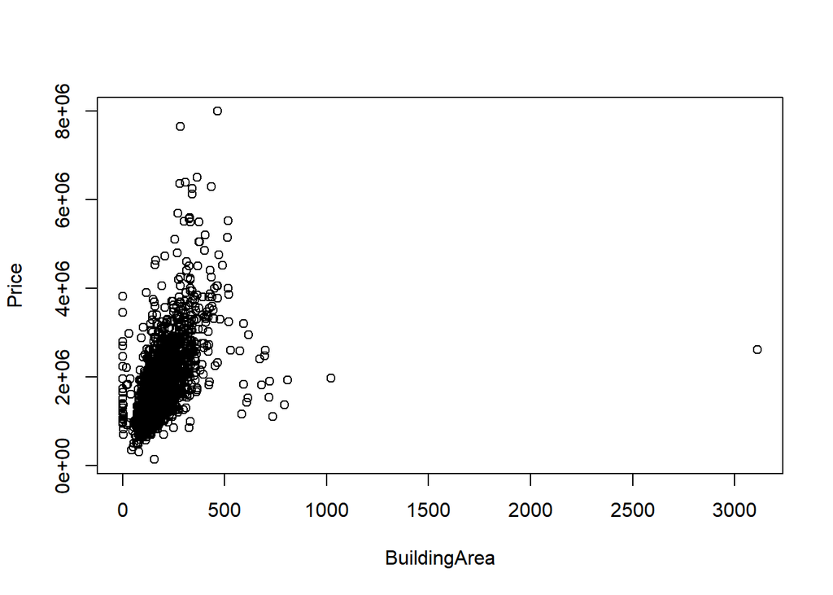

```r
plot(Price~BuildingArea, data=df_dt_fe_na_dc)
```

In this plot, there’s a noticable positive correlation even thou the correlation were < 0.5. Therefore, we’ll try to create linear regression prediction based on this correlation.

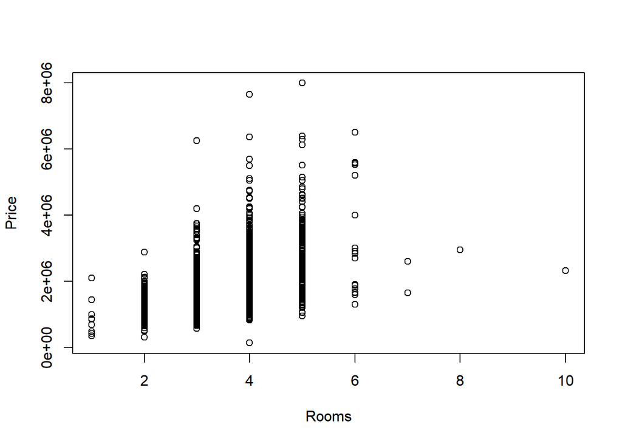

```r
plot(Price~Rooms, data=df_dt_fe_na_dc)
```

In this plot, there’s a noticable positive correlation but with large variation in each Rooms value. Therefore, we’ll try to create linear regression prediction based on this correlation.

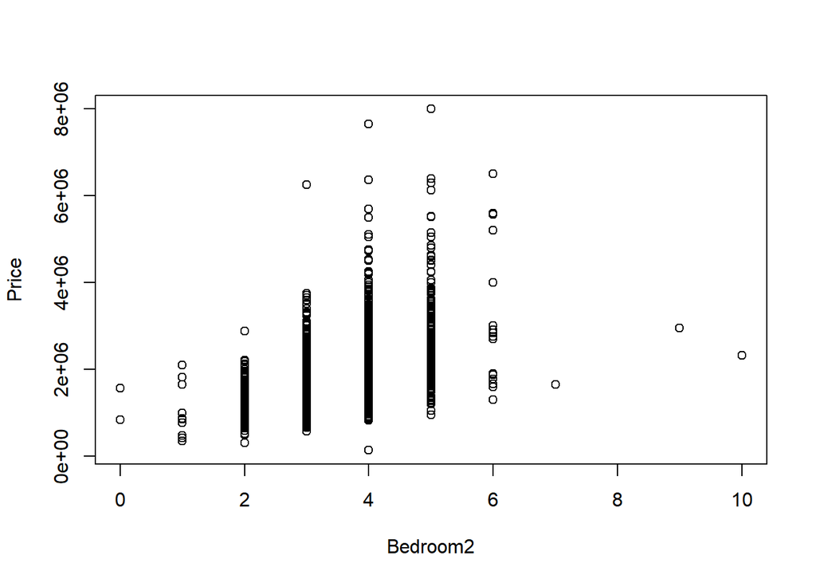

```r
plot(Price~Bedroom2, data=df_dt_fe_na_dc)
```

In this plot, there’s also a noticable positive correlation but with large variation in each Bedroom2 value. Therefore, we’ll try to create linear regression prediction based on this correlation also.

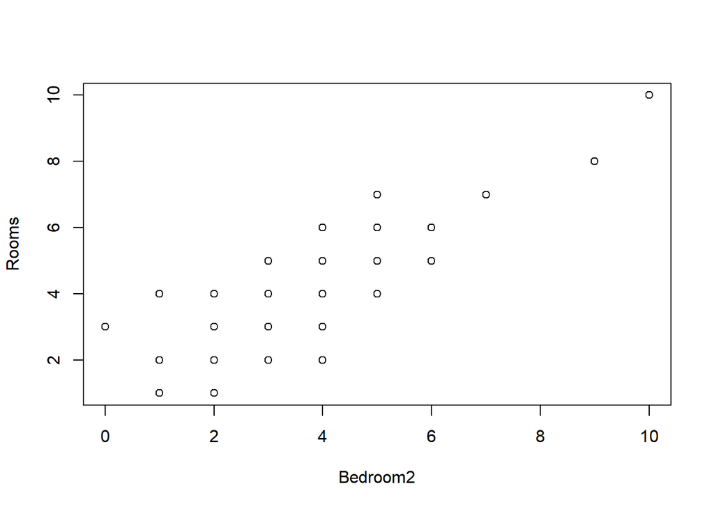

```r
plot(Rooms~Bedroom2, data=df_dt_fe_na_dc)
```

Next, we investigate whether for each independent variables exist correlation. From the correlation value and scatter plote above, there is strong correlation between Rooms and Bedroom2, so we wouldn’t use multinomial linear regression.

```r
names(df_dt_fe_na_dc)
```

```
##  [1] "Distance"      "BuildingArea"  "Propertycount" "Rooms"
##  [5] "Price"         "Bedroom2"      "Bathroom"      "Car"
##  [9] "Landsize"      "YearBuilt"
```

```r
df_input_lr = df_dt_fe_na_dc[c(2,4,5,6)]
head(df_input_lr)
```

```
##     BuildingArea Rooms   Price Bedroom2
## 134           82     2 1275000        2
## 136          198     3 2850000        3
## 137          133     3 1850000        3
## 139           81     2 1436000        2
## 143          180     4 2300000        4
## 146          159     3 1800000        3
```

### Create train and test dataset

```r
# Set index dan proporsi data training dan test
index = 1:nrow(df_input_lr)
testindex = sample(index, 0.2*length(index)) # Proporsi test dataframe sebesar 20%, dan train dataset 80%

# Membuat data train dan test berdasarkan index
testset = df_input_lr[testindex,]
trainset = df_input_lr[-testindex,]

# Perbandingan jumlah baris dataframe
nrow(df_input_lr)
```

```
## [1] 1956
```

```r
nrow(testset)
```

```
## [1] 391
```

```r
nrow(trainset)
```

```
## [1] 1565
```

### Feature Scalling

```r
#install.packages("conflicted")
#library(conflicted)
#conflict_prefer("apply", "base")

#Deklarasi untuk fungsi normalisasi z
normalisasi=function(x){
  xm=colMeans(x) # Mencari means per kolom
  jb=dim(x)[1] # untuk kolom 1 dimensi ada berapa
  xc=x-rep(xm,each=jb) #rep = repetition (mengulang, ), xm = rata-rata
  sdx=apply(x,2,sd) # mencari standar deviasi
  xstd=xc/rep(sdx,each=jb) # x nya dibagi standar deviasi
  output=data.frame(xstd)
  #output=data.frame(xstd,x)
  return(output)
}

# Normalisasi
#df_input_mlr = normalisasi(df_input_lr)
#head(df_input_mlr)
```

### Linear Regression Applied

```r
# Create Bivariate Linear Regression
regressionModel1 = lm(formula=Price~BuildingArea, data=trainset)
#View(regressionModel1)
summary(regressionModel1)
```

```
##
## Call:
## lm(formula = Price ~ BuildingArea, data = trainset)
##
## Residuals:
##      Min       1Q   Median       3Q      Max
## -8782702  -436036  -127906   267609  5284954
##
## Coefficients:
##               Estimate Std. Error t value Pr(>|t|)
## (Intercept)  1193684.6    34981.3   34.12   <2e-16 ***
## BuildingArea    3276.7      156.4   20.95   <2e-16 ***
## ---
## Signif. codes:  0 '***' 0.001 '**' 0.01 '*' 0.05 '.' 0.1 ' ' 1
##
## Residual standard error: 744400 on 1563 degrees of freedom
## Multiple R-squared:  0.2193, Adjusted R-squared:  0.2188
## F-statistic:   439 on 1 and 1563 DF,  p-value: < 2.2e-16
```

```r
# Create Bivariate Linear Regression
regressionModel2 = lm(formula=Price~Rooms, data=trainset)
#View(regressionModel1)
summary(regressionModel2)
```

```
##
## Call:
## lm(formula = Price ~ Rooms, data = trainset)
##
## Residuals:
##      Min       1Q   Median       3Q      Max
## -1950519  -430237  -122801   284763  5427199
##
## Coefficients:
##             Estimate Std. Error t value Pr(>|t|)
## (Intercept)   116392      71813   1.621    0.105
## Rooms         491282      20139  24.395   <2e-16 ***
## ---
## Signif. codes:  0 '***' 0.001 '**' 0.01 '*' 0.05 '.' 0.1 ' ' 1
##
## Residual standard error: 717000 on 1563 degrees of freedom
## Multiple R-squared:  0.2758, Adjusted R-squared:  0.2753
## F-statistic: 595.1 on 1 and 1563 DF,  p-value: < 2.2e-16
```

```r
regressionModel3 = lm(formula=Price~Bedroom2, data=trainset)
#View(regressionModel2)
summary(regressionModel3)
```

```
##
## Call:
## lm(formula = Price ~ Bedroom2, data = trainset)
##
## Residuals:
##      Min       1Q   Median       3Q      Max
## -1966232  -425398  -126398   287685  5417850
##
## Coefficients:
##             Estimate Std. Error t value Pr(>|t|)
## (Intercept)   157563      71191   2.213    0.027 *
## Bedroom2      484917      20178  24.032   <2e-16 ***
## ---
## Signif. codes:  0 '***' 0.001 '**' 0.01 '*' 0.05 '.' 0.1 ' ' 1
##
## Residual standard error: 719900 on 1563 degrees of freedom
## Multiple R-squared:  0.2698, Adjusted R-squared:  0.2693
## F-statistic: 577.5 on 1 and 1563 DF,  p-value: < 2.2e-16
```

```r
head(testset)
```

```
##       BuildingArea Rooms   Price Bedroom2
## 13104       186.36     4 2600000        4
## 10437       220.00     3 2700000        3
## 7831         70.00     2 1060000        2
## 12514       155.00     3 1620000        3
## 19798       154.00     3 1470000        3
## 34413       294.00     6 2905000        6
```

```r
predict(regressionModel1, head(testset))
```

```
##   13104   10437    7831   12514   19798   34413
## 1804326 1914553 1423052 1701569 1698293 2157028
```

```r
predict(regressionModel2, head(testset))
```

```
##   13104   10437    7831   12514   19798   34413
## 2081519 1590237 1098956 1590237 1590237 3064082
```

```r
predict(regressionModel3, head(testset))
```

```
##   13104   10437    7831   12514   19798   34413
## 2097232 1612315 1127398 1612315 1612315 3067067
```